# individual1

Mike Zaino - mzaino16

2/19/2020

```r
dat <- readxl::read_xls('/Users/TheemikezanilyMac/Documents/School/DS 202/ds202_lab3/GSS.xls')
predictors <- c("Year", "Jobsatif", "Happy", "Religion", "Education", "Addiction", "Cityproblems", "Space", "Party", "Race", "Sex", "Schoolyear", "Age", "Children", "Status", "ID", "Ballot")
names(dat) <- predictors
dat$Year <- as.factor(dat$Year)
```

1. How does the happiness of a respondent relate to the marriage status?

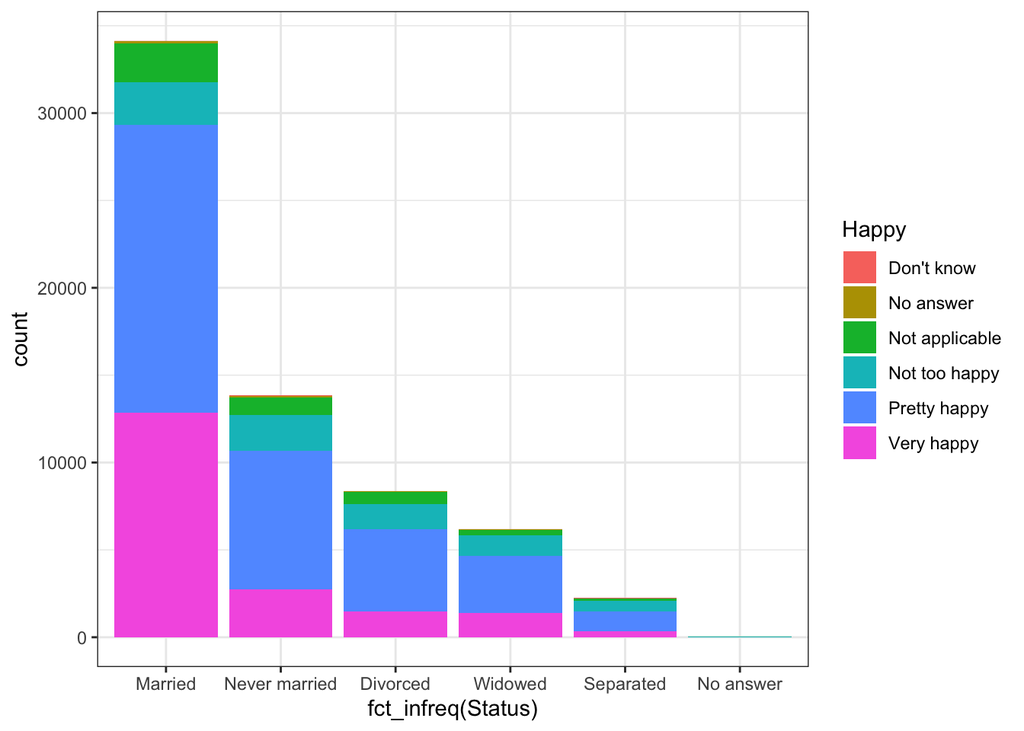

```r
ggplot(dat, aes(x=fct_infreq(Status), fill=Happy))+geom_bar()+theme_bw()
```

Yes, the percentage of people who are very happy and pretty happy who are married is highest compared to all other answers. So, yes, marriage does affect happiness.

2. Does the sex of the respondent affect the relationship you found in Q1?

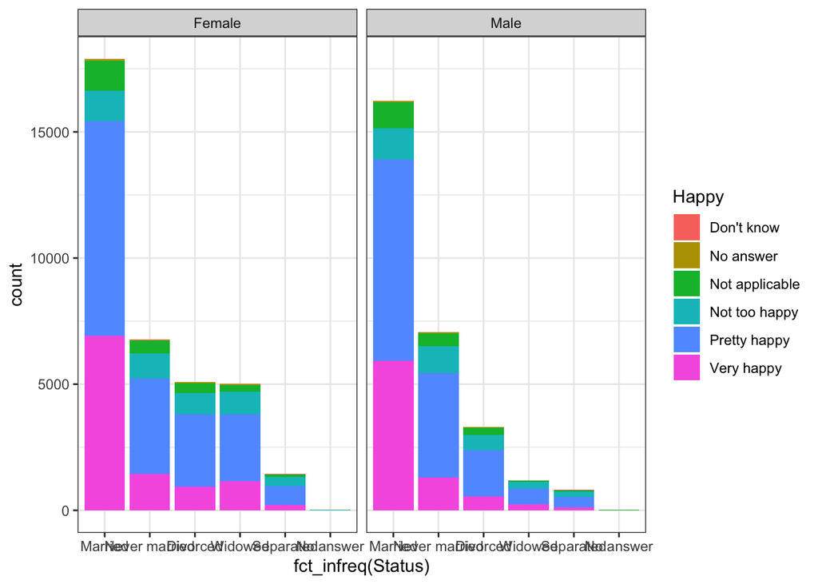

```r
ggplot(dat, aes(x=fct_infreq(Status), fill=Happy))+geom_bar()+theme_bw() +facet_wrap(~Sex)
```

No, it does not. Clearly from the above graph, males and females have about the same percentage of pretty happy and very happy people.

3. How does the happiness of a respondent relate to the political party affiliation?

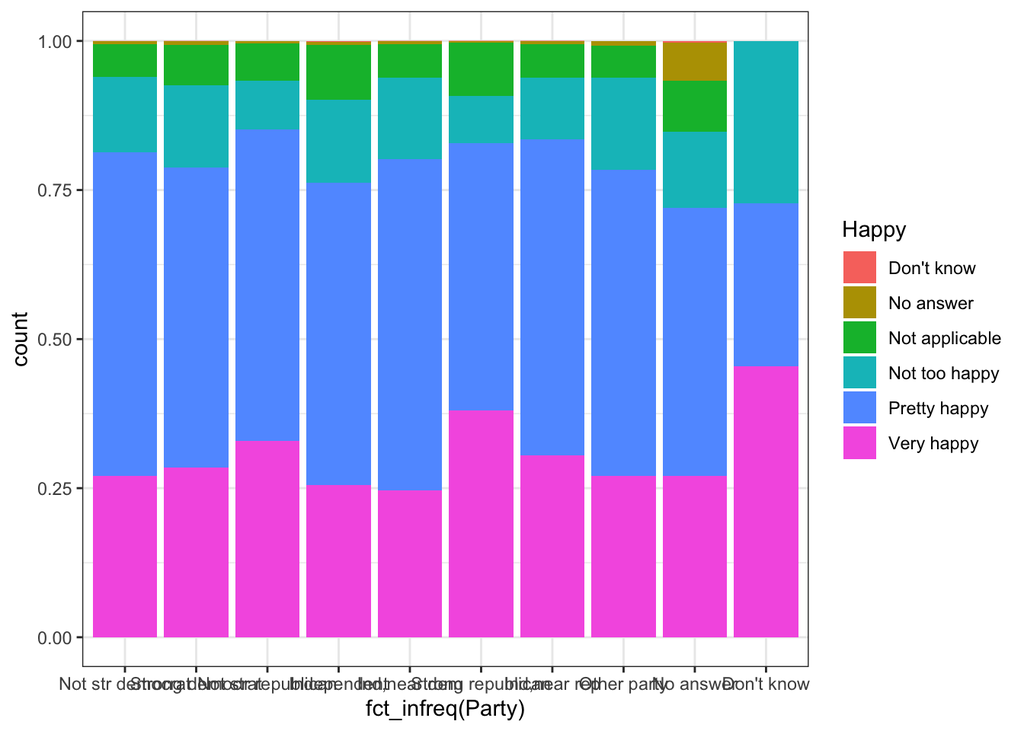

```r
ggplot(dat, aes(x=fct_infreq(Party), fill=Happy))+geom_bar(position="fill")+theme_bw()
```

Looking at the above graphs, it is tough to tell if there is a difference between parties. THere is small variations in the data but nothing to say one way or the other. So, political party has no affect on happiness.

Does your religion and political party association have any correlation? Does your education level and party dictate views on the national education system? Does your religious preference determine your marital status and amount of children? Is there a time when there was a political party affiliation shift?